# Data Science Capstone Project: NLP Ngram Prediction Application

Ben H.  
10/31/2017

### Capstone Project Overview

1. Use R Software's text mining and natural language processing capabilities to:
   - Mine a set of provided source text documents
   - Create a predictive text model
2. Create a shiny app data product that uses the predictive text model to predict next words
3. Create an R Presentation to pitch your predictive text application

### Predictive Text Model: Building Text Library

Process for Text Library Construction:

1. Sample provided source text files. Due to the size of the source text files analyzing the full source files is not feasible for this application.
2. Utilize R 'tm' package to:
   - Clean sampled text of numbers, punctuations, profanity, stopwords, etc. and save as a new file that includes only the desired text to be used for the predictive model.
   - Create a separate ngram library for unigrams, bigrams, trigrams, and quadgrams included in the sampled text. These libraries will form the backbone of the models predicition capabilities

### Ngram Prediction Model: Prediction Algorithm

The prediction model used to construct this algorithm is Katz's Back-Off Model

1. The model estimates the conditional probability of a word based on that words history in the ngram.
   - For our algorithm we have used quadgrams as the ngram.
2. The estimation is done by backing-off to smaller ngram models under certain conditions. For example if the input phrase does not explicitly appear in our quadgram library.
   - For our algorithm the model may back-off to trigrams and then bigrams if necessary

The R file library for this algorithm can be found on Github at this link:

- [R Prediction Algorithm](https://github.com/pulsar135/projrepo)

### Ngram Prediction Shiny Application

- The app allows the user to input a word or phrase for which they would like the next word
- It then takes the input phrase and puts it through the prediction model and returns the three words with the highest probabilities of being the next word in the input phrase
- An image of the app is below and the working app can be found at this link:
  - [Ngram Predicition Shiny App](https://pulsar135.shinyapps.io/projrepo/)

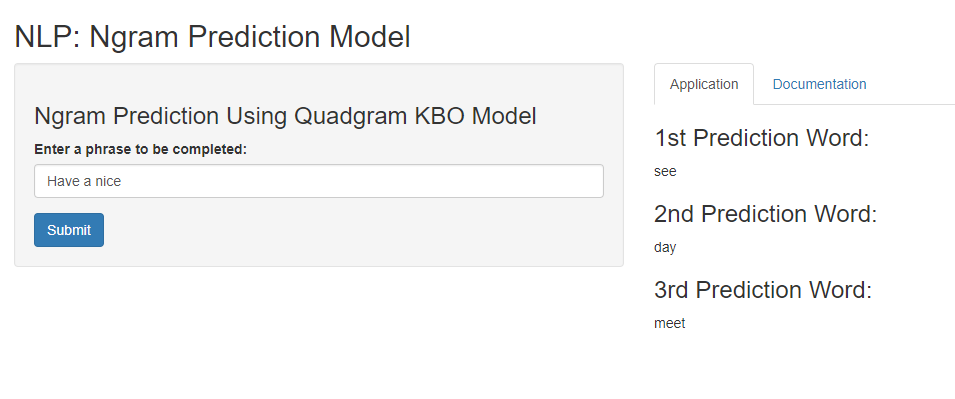